# Manuel de l’application Coral Growth

# IT

## Structure

L’application est divisé en deux fichiers : ui.R et server.R .

Le script ui.R contient tous les élèments à afficher à l’utilisateur.  
Le script server.R contient toute la partie logique (importation du jeu de donnée, transformation, calculs, …) .

Les noms des variables ont un sens pratique :

- ui_nom_de_variable : variable seulement utilisé dans le script ui.R .
- u_nom_de_variable : variable crée dans ui.R, utilisé dans server.R .
- s_nom_de_variable : variable crée dans server.R, utilisé dans server.R .

Les variables “*uiOutput*” sont un peu spéciales, elles sont crées dans ui.R, pour être configuré dans server.R .  
L’intérêt est de pouvoir utilisé des variables provenant du script server.R.  
Elles sont paramétrés dans server.R comme n’importe quelle variable *nomInput* (inputId, label, …).

## server.R

### Importation

L’adresse URL est contenu dans la variable coral_url. L’URL est générer via un fichier en ligne Google sheets.

[figure not shown]

Pour cela il faut aller dans *Fichier > Publier sur le web*, puis choisir : *Intégrer > Valeurs séparées par des virgules (.csv)*.

[figure not shown]

_______________________________________________________________________________

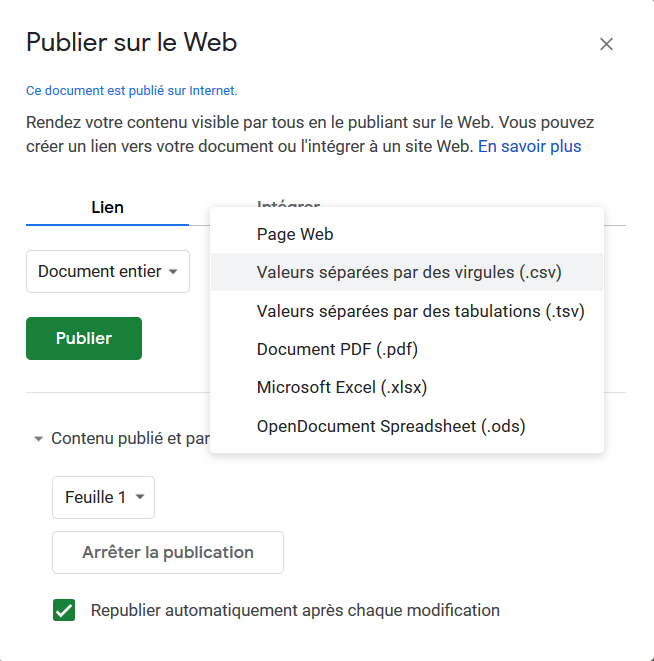

Le lien de partage au format csv contenu dans *coral_url* sera lu par la fonction *read_csv*. Cette fonction va importer le tableau de donnée et les mettre au bon format. Une grande source d’erreur provient de l’importation, il est important de respecter le nom des colonnes, ne pas jouer avec le format des colonnes, surtout pour la date qui devient facilement un problème.  
Dans le tableau de donnée de base, la plupart des colonnes ont le format “texte brute”, seuls les colonnes “id”, “weight”, “temperature” et “salinity” ont un format numérique.

## À notifier

### Colonne ratio

La colonne *ratio* est calculé à partir de la première valeur encodée de la masse squelettique avec la valeur suivante pour chacun des ID.

Si certaines valeurs n’ont pas été rentrées lors de la première date, le ratio ne peut être calculé.

### Colonne delta_date

La colonne *delta_date* est une valeur arrondis au jour près.

### Variable dateRangeInput

La variable *dateRange* possède une plage minimum qui débute avec la date la plus ancienne et maximum qui est la **date actuel** de l’ordinateur.